# Introduzione a R

13/10/2020

## Let’s start!

## use…R!

- Avete **installato** R?
- Quanti di voi hanno mai **usato** R o un altro linguaggio di programmazione?

Perchè usare R?

- **Analisi riproducibili**
- Free, **Open-Source**
- In continua **evoluzione** ed espansione
- Large **community**

[figure not shown]

## use…R!

Prima di tutto…. proviamo **R**! ma **Rstudio** è più semplice:

[figure not shown]

💥 **Attenzione**! R e Rstudio non sono la stessa cosa! **R** è un **linguaggio-ambiente di programmazione**, mentre **Rstudio** è un **IDE** che rende R più **user-friendly**

## Pacchetti per tutti!

R fornisce una serie di pacchetti (**packages**) che racchiudono funzioni molto utili e di vario genere. Per esempio con i seguenti comandi:

```r
install.packages("xlsx") #Installiamo il pacchetto "xlsx"
library(xlsx) #Dopo averlo installato lo richiamiamo
```

installiamo il pacchetto `xlsx` e lo richiamiamo nella nostra sessione. Questo pacchetto ci permette di caricare all’interno di R dati da Excel.

\(\rightarrow\) per ogni cosa che volete fare esiste un pacchetto corrispondente! Se trovate questo errore in futuro:

```r
Error in library(dplyr) : there is no package called dplyr
```

significa che dovete installare il pacchetto `dplyr`. 🌛 **Consiglio**: errori/bug cercate su google o [stackoverflow](https://stackoverflow.com)!

[figure not shown]

## Un po’ di basi

## Operazioni

Per le operazioni di somma, sottrazione, moltiplicazione e divisione si utilizzano \(+ - * /\). Per l’elevazione a potenza si usa: \(**\) o ^.

```r
(4+5)*3
```

Gli operatori logici corrispondono invece ai seguenti simboli:

```r
& #AND
| #OR
> #maggiore
< #minore
== #uguale
!= #diverso
>= #maggiore uguale
<= #minore uguale
```

💥 **Attenzione**: I simboli `=` e `<-` si usano per assegnare un valore a una variabile

```r
pluto = "ciao"
```

diverso da `==` (operazione logica che definisce l’uguale)!!

## Operazioni

Vediamo qualche esempio insieme

```r
4==10
5!=10
(4==4)&(10!=1)
8>=10
3<20
```

💥 **Attenzione**:

```r
TRUE==1
```

```r
FALSE==0
```

## Altri comandi fondamentali

**Aiuto?**

```r
help("+") #cerchiamo aiuto per capire l'uso di +
```

**Cambiare working directory?**

```r
setwd("il_mio_path")
```

**Vedere cosa c’è nella mia working directory?**

```r
ls()
```

**Cancellare quello che abbiamo trovato nella working directory?**

```r
rm(list = ls()) #Cancelliamo tutti gli elementi presenti
rm(pluto) #cancelliamo l'oggetto pluto
```

## Caricamento dati

Come caricare i dati? dipende… 😮

Per prima cosa vedete il **formato** del vostro documento (xlsx, csv, xls, txt etc), in generale, vi sarà un comando corrispondente:

```r
read.table("path/file_name.txt") #formato txt
read.csv("path/file_name.csv") #formato csv
read.xlsx("path/file_name.xlsx") #formato xlsx
```

etc.. se siete indecisi usate l’`help`, google, stackoverflow o [R-bloggers](https://www.r-bloggers.com/)! 😄

oppure andate su Files \(\rightarrow\) Import Datasets \(\rightarrow\) …

Proviamo insieme!

Qualche funzione utile:

```r
colnames(db)
rownames(db)
```

## Ma le variabili?

## Tipologie di variabili

Carichiamo il file di esempio:

```r
DB <- read.csv("Datasets/HappinessAlcoholConsumption.csv")
```

e vediamo qualche esempio di variabile:

```r
str(DB) #con questo comando vediamo la struttura del dataset DB
head(DB) #Vediamo le prime 6 righe/osservazioni
View(DB) #Vediamo in finestra separata il dataset intero
```

1. Numeric : `HappinessScore`
2. Factor (Variabili Qualitative): `Country`
3. Integer: `Beer_PerCapita`

ma abbiamo anche character, logical, `NA`, `NaN`.

## Tipologie di oggetti (alcuni)

**Vettori**

```r
pluto <- c(1:100) #creaiamo un vettore con valori da 1 a 100
pluto1 <- seq(1,500,5) #creaiamo un vettore con valori da 1 a 500 ogni  5 valori
pluto2 <- rep(10,5) #creiamo un vettore dove si ripete il valore 10 5 volte
pluto[3] #richiamiamo l'elemento del vettore pluto che sta nella 3 posizione
pluto[1:3] #richiamiamo l'elemento del vettore pluto che sta nella 1,2,3 posizioni
is.vector(pluto) #verifichiamo che pluto sia un vettore
length(pluto) #dimensione del vettore pluto?
sort(pluto) #ordiniamo pluto
pluto/5 #dividiamo ogni elemento di pluto per 5
```

proviamo insieme!

## Tipologie di oggetti (alcuni)

**Matrici**

```r
pippo <- matrix(data = 10, nrow = 10, ncol = 5) #Creiamo una matrice
#con 10 righe e 5 colonne contenente solo 10
pippo1 <- matrix(data = pluto, nrow = 20, ncol = 5, byrow = T) #mettiamo pluto in
#pippo! partendo dalle righe (byrow)
pippo2 <- cbind(pluto,pluto1) #Uniamo i due vettori per colonna
pippo3 <- rbind(pluto,pluto1) #Uniamo i due vettori per riga
dim(pippo) #Dimensione di pippo?
ncol(pippo) #numero di colonne di pippo?
nrow(pippo) #numero di righe di pippo?
is.matrix(pippo) #Check che pippo sia una matrice
```

💥 Se non vi ricordate \(\rightarrow\) `help(matrix)`!

## Tipologie di oggetti (alcuni)

**Data frame**

```r
is.data.frame(DB)
rick <- data.frame(pippo2[1:20,]) #creiamo un dataframe di nome rick
#che prende le prime 20 osservazioni di pippo2
dim(rick) #Dimensione? nrow, ncol etc come matrix
colnames(rick) #Nomi colonna?
rownames(rick) #Nomi riga?
rownames(rick) <- letters[1:dim(rick)[1]] #rinominiamo le righe di rick
#come le prime 20 lettere dell'alfabeto
rick[10,2] #Richiamiamo l'elemento della 10 riga e 2 colonna
rick$pluto #richiamo la variabile pluto (prima colonna)
```

❓ Che differenza c’è tra `data.frame` e `matrix`?

## Prima di continuare..

1. Domande ❓
2. Ma perdo tutto quello che ho caricato/scritto? No ovviamente 😄

```r
save(rick, file = "your_path/il_mio_primo_rda.rda") #salviamo l'oggetto
#rick in il_mio_primo_rda
load("your_path/il_mio_primo_rda.rda") #e lo ricarico sulla working directory!!
```

## Un po’ di analisi descrittiva

## Variabili qualitative

### Tabelle di Frequenza

Frequenze assolute

```r
fa_h <- table(DB$Hemisphere)
addmargins(fa_h) #Aggiungi totale alla tabella fa_reg
```

```
##
##  both north  noth south   Sum
##     5    92     4    21   122
```

## Variabili qualitative

### Tabelle di Frequenza

Frequenze relative

```r
fa_h/nrow(DB)
```

```
##
##       both      north       noth      south
## 0.04098361 0.75409836 0.03278689 0.17213115
```

```r
fr_h <- prop.table(fa_h)
addmargins(fr_h) #Aggiungi totale alla tabella fr_reg
```

```
##
##       both      north       noth      south        Sum
## 0.04098361 0.75409836 0.03278689 0.17213115 1.00000000
```

## Variabili qualitative

### Grafici

[figure not shown]

## Variabili qualitative

### Grafici

Barplot

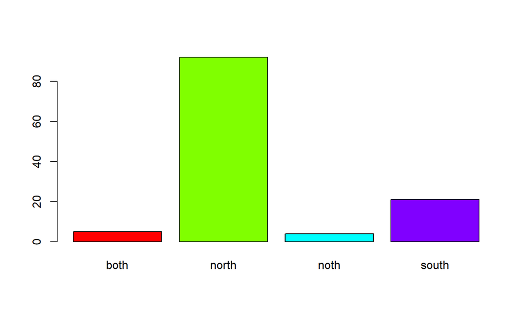

```r
barplot(fa_h, col = rainbow(length(levels(DB$Hemisphere))))
```

## Variabili qualitative

### Grafici

Grafico a torta

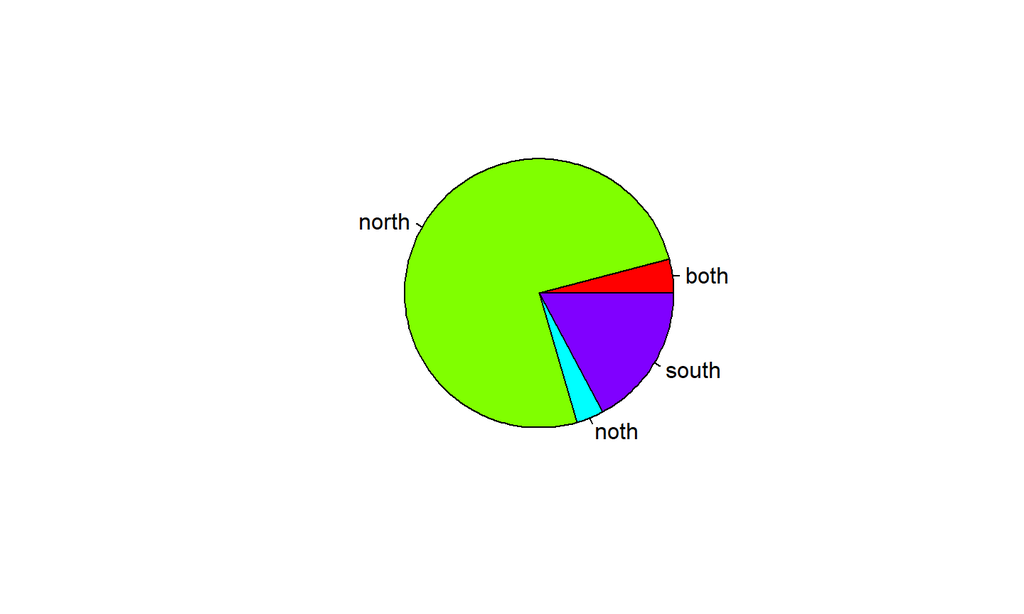

```r
pie(fa_h, col = rainbow(length(levels(DB$Hemisphere))))
```

## Variabili quantitative

### Tabelle di Frequenza e altro

Per le tabelle di frequenza assolute e relative valgono gli stessi comandi usati per la variabile qualitativa `Hemisphere`.

Con le variabili quantitative abbiamo anche:

```r
min(DB$HappinessScore)
```

```
## [1] 3.069
```

```r
max(DB$HappinessScore)
```

```
## [1] 7.526
```

## Variabili quantitative

### Tabelle di Frequenza e altro

```r
summary(DB$HappinessScore)
```

```
##    Min. 1st Qu.  Median    Mean 3rd Qu.    Max.
##   3.069   4.528   5.542   5.525   6.477   7.526
```

```r
mean(DB$HappinessScore)
```

```
## [1] 5.524828
```

```r
median(DB$HappinessScore)
```

```
## [1] 5.542
```

## Variabili quantitative

### Grafici

Istogramma

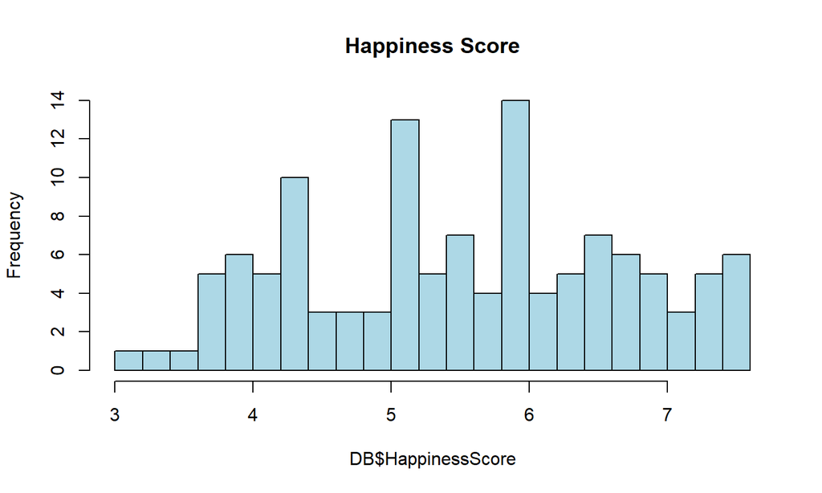

```r
hist(DB$HappinessScore, breaks = 20, col = "lightblue", main = "Happiness Score") #breaks decide gli intervalli!
```

## Variabili quantitative

### Grafici

💥 **Attenzione** agli intervalli!

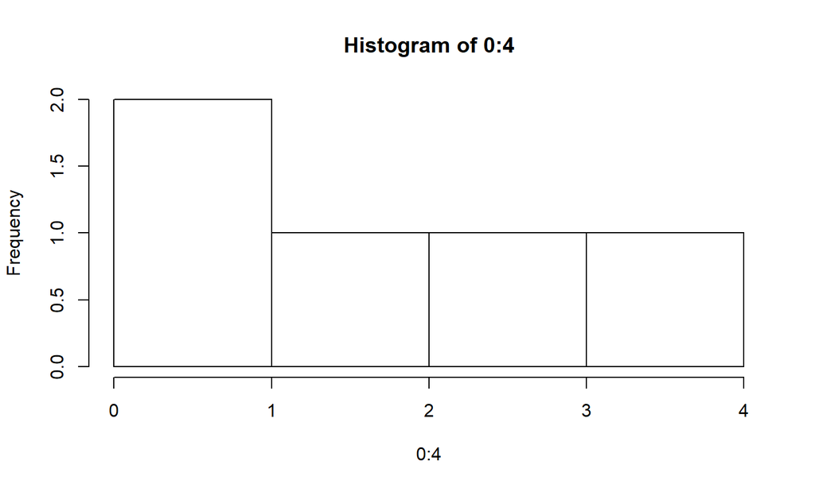

```r
hist_plot <-hist(0:4)
```

```r
hist_plot
```

```
## $breaks
## [1] 0 1 2 3 4
##
## $counts
## [1] 2 1 1 1
##
## $density
## [1] 0.4 0.2 0.2 0.2
##
## $mids
## [1] 0.5 1.5 2.5 3.5
##
## $xname
## [1] "0:4"
##
## $equidist
## [1] TRUE
##
## attr(,"class")
## [1] "histogram"
```

## Variabili quantitative

### Grafici

Boxplot

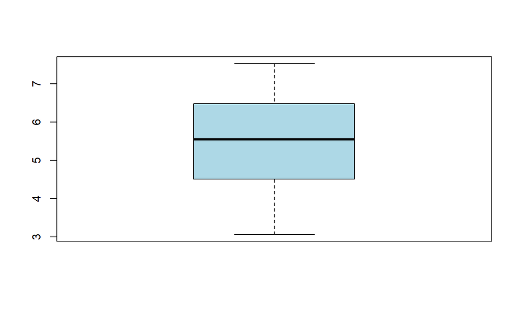

```r
boxplot(DB$HappinessScore,col = "lightblue")
```

## Vuoi diventare un supeR useR?

## Cosa fare?

- Allenarsi 🏈
- Risolvere i bug da soli 🐛
- Documentarsi 📖:
  - Google, [R-bloggers](https://www.r-bloggers.com/), …
  - [R Cookbook](https://www.amazon.com/Cookbook-OReilly-Cookbooks-Paul-Teetor/dp/0596809158/ref=dp_rm_title_0)
  - [R in a Nutshell](https://www.amazon.com/R-Nutshell-In-OReilly/dp/144931208X/ref=dp_rm_title_3)
  - [Learning R](https://www.amazon.com/Learning-R-Richard-Cotton/dp/1449357105/ref=dp_rm_title_1)
  - [An Introduction to Statistical Learning: with Applications in R](https://www.amazon.com/Introduction-Statistical-Learning-Applications-Statistics/dp/1461471370/ref=pd_sim_14_1?ie=UTF8&dpID=41oQwj8rS0L&dpSrc=sims&preST=_AC_UL160_SR106%2C160_&refRID=0CHFMDE74NCF14EF71EM)

Trovate tutto il materiale di questa lezione [qui!](https://github.com/angeella/Psicometria_Mod_A)